# RProject

Giselle Guerra

6/5/20

### Problem 1

1. Here we are creating functions to do the following operations:  
   Our test vector is X = 1:100, we are subtracting the mean and dividing by the standard deviation of each X<sub>i</sub> then returning the standard deviation of all the X<sub>i</sub>’s.

Result: 1

```r
#1.A
find_values <- function (v){
  the_mean = mean(v)
  the_sd = sd(v)
  vec_for_sd = c()

  for (i in v){
    value = (i - the_mean) / the_sd
    vec_for_sd = c(vec_for_sd, value)
  }
  #return (sd(vec_for_sd))
}
find_values(c(1:100))
```

2. Takes in the vector X = 1:100 and returns the values (x<sub>i</sub> - $\overline{x}$ / s , x<sub>i</sub> + $\overline{x}$ / s) where s is that sample standard deviation.  
   Result: ( -7.522984 , 108.523 )

```r
#1.B
find_ssd <- function (vec){
  m = mean(vec)
  s = 0
  for (i in vec){
    sum_of_vec = (i - m) ^ 2
    s = sum_of_vec + s
  }

  ssd = sqrt (s / (length(vec) - 1))  #find the sample standard deviation

  x = m - 2*ssd
  y = m + 2*ssd
  #print (x)
  #print(y)   #prints two values  (x,y)
}

find_ssd(c(1:100))
```

3. We are Finding the mean after removing any values three times the standard deviation from the mean and calculating the mean after removing said values. Test vector X = c(1:100,200,300)  
   Result: 50.5

```r
#1.C
remove_it <- function (vec){
   num_to_remove = 3*sd(vec) + mean (vec)  #finds values too large or too small
   new_vec = c()
   new_vec = vec[vec<= num_to_remove] #removes values

   #return (mean(new_vec))       #returns the mean of the vector
}

newvec = c(1:100, 200, 300)
remove_it (newvec)
```

### Problem 2

Here we are simulating a fair coin flip.

```
##    n =10   n =100  n =1000 n =10000 n =1e+05
##     0.60     0.55     0.60     0.45     0.60
```

3. We are now finding the error based on our calculations from (B). The error of a coin flip is equal to: |0.5 - P(head)|  
   Result:

```
##    n =10   n =100  n =1000 n =10000 n =1e+05
##     0.10     0.05     0.10     0.05     0.10
```

4. As n increases, we should be see the error approach zero because as we increase the value n we increase the number of chances to get heads, moving towards the true probability. This is called the law of large numbers

### Problem 3

We are evaluating the possible orderings of 7 objects

1. We are using the sample function to draw from 7 values without replacement.  
   Our vector is: “1” “7” “2” “5” “3” “6” “4”
2. We are now repeating (A) 100,000 times using the sappy function. We Are finding how many of the 100,000 rounds started with the number one.  
   Result: 14,355
3. We are taking the results from (B) and finding which of the 100,000 rounds started with 3 and ended with 7.  
   Result: 2407
4. There are 5040 unique orderings of 7 values

### Problem 4

Here we are simulating a binomial random variable. The probability that a student doesn’t turn in their homework is .05

Is it symmetric? No, our histogram is skewed right and the right side is not a mirror to its left side.

```
## [1] 0
```

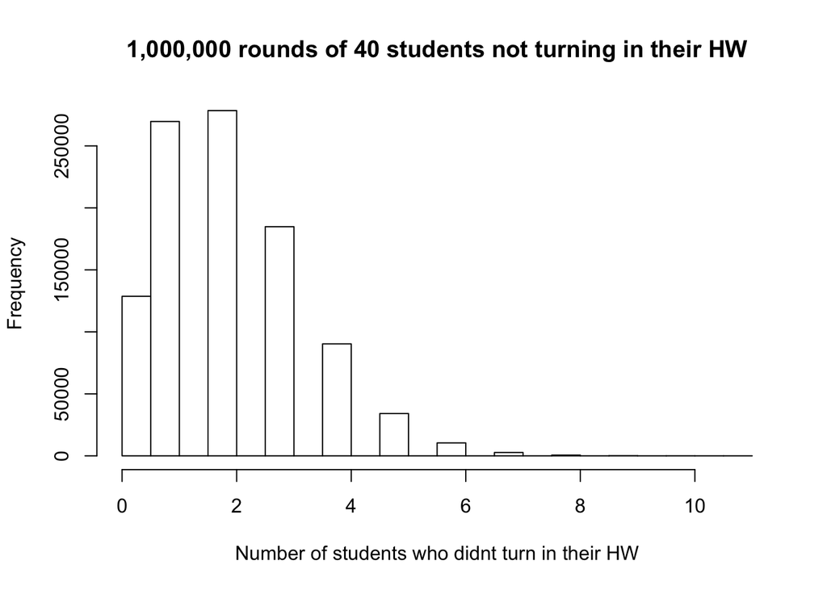

3. The average number of students who do not complete their homework is 1.825 meaning one to two students in a class size of 40. The standard deviation based on part (B) is 1.377
4. The probability that all students will do their homework is 12.83%
5. The Probability that at least 2 students do not do their HW is 60.14%
6. The median number of students who didnt do their Hw is 2

### Problem 5

Here we are reading in the crimes.csv file  
A) We are are creating a scatter plot and the pink line is our regression line

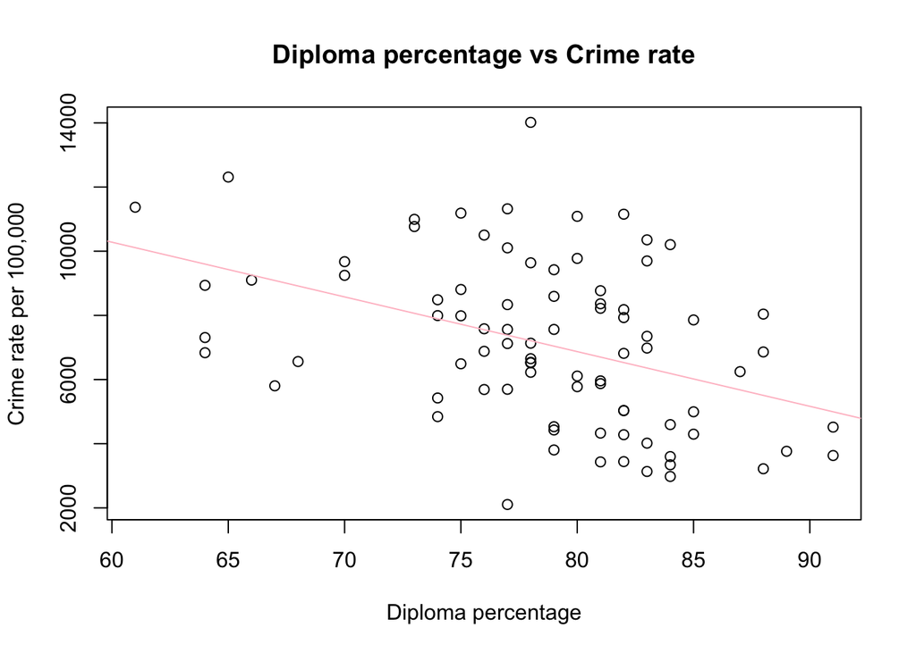

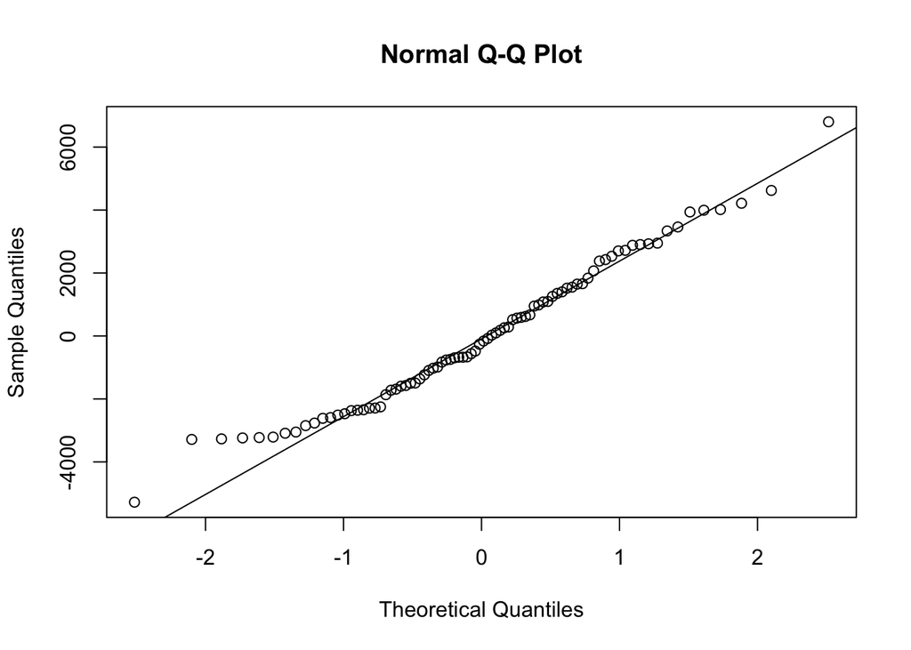

It does appear that they are normally distributed since the points seem to fall about a straight line so we can say errors follow a normal distribution.

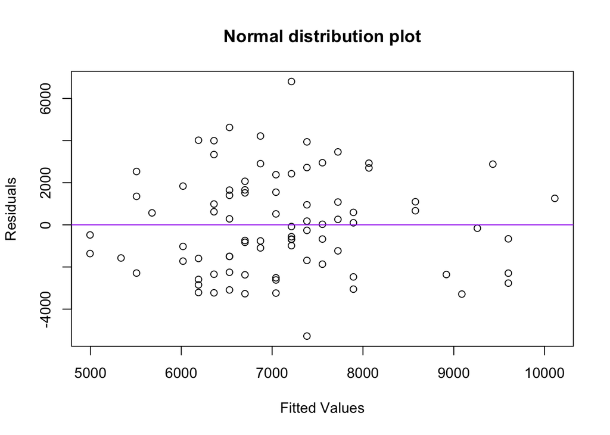

The variance of the errors appear to be a constant because its not fanning out or increasing or decreasing. There is also no pattern so we can claim their isn’t any dependency.

7. We found the confidence interval at 95% and we have that we are 95% confident that the true mean slope is in between -253.2798 and -87.87061 and the intercept is in between 13,997.3245 and 27,037.87538. This suggest that there is a significant linear relationship because we do not pass through the value zero.

## Appendix Code

```r
knitr::opts_chunk$set(echo = FALSE)
#1.A
find_values <- function (v){
  the_mean = mean(v)
  the_sd = sd(v)
  vec_for_sd = c()

  for (i in v){
    value = (i - the_mean) / the_sd
    vec_for_sd = c(vec_for_sd, value)
  }
  #return (sd(vec_for_sd))
}
find_values(c(1:100))


#1.B
find_ssd <- function (vec){
  m = mean(vec)
  s = 0
  for (i in vec){
    sum_of_vec = (i - m) ^ 2
    s = sum_of_vec + s
  }

  ssd = sqrt (s / (length(vec) - 1))  #find the sample standard deviation

  x = m - 2*ssd
  y = m + 2*ssd
  #print (x)
  #print(y)   #prints two values  (x,y)
}

find_ssd(c(1:100))


#1.C
remove_it <- function (vec){
   num_to_remove = 3*sd(vec) + mean (vec)  #finds values too large or too small
   new_vec = c()
   new_vec = vec[vec<= num_to_remove] #removes values

   #return (mean(new_vec))       #returns the mean of the vector
}

newvec = c(1:100, 200, 300)
remove_it (newvec)


#2A
flipCoin <- function (){
  flipTheCoin = sample (c(1,2), 20, replace = TRUE)   # 1 is heads, 2 is tails
  prob_of_heads = (sum(flipTheCoin == 1)) / length(flipTheCoin) #calculates the probability of heads
  #print (prob_of_heads)
}
flipCoin()  #calls function


#2B
val_of_n = c(10,100,1000,10000,100000) #our vector for the amount of n's
many_rolls = sapply(val_of_n, function(n){
  flipTheCoin = sample (c(1,2), 20, replace = TRUE, prob = c(1/2, 1/2))   # 1 is heads, 2 is tails
  prob_of_heads = (sum(flipTheCoin == 1)) / length(flipTheCoin) #calculates the probability of heads
  return (prob_of_heads)

})
names(many_rolls) = paste("n =",val_of_n,sep = "")
many_rolls


#2C
abs_of_error= abs(.50 - many_rolls)
print (abs_of_error)


#3A
values = as.character(1:7) #creates vector
pick_one = sample(values, 7, replace = FALSE) #simulates a permutation


#3B
n_draws = sapply(1:100000,function(i){ #simulating part A 100,000 times
  the_draw = c(sample(pick_one))  #creates a vector of the values
})
prob_one = sum(n_draws[1,] == 1)  #finds the permuations that start with one
#print(prob_one)


#3C
prob_one_three = sum(n_draws[1,] == 3 & n_draws [7,] == 7) #finds the permuatations that start with 3 and end with 7
#print (prob_one_three)


#3D
all_draws = sapply(1:100000,function(i){
  one_order = paste(n_draws[,i],collapse = "")
})
#length(unique(all_draws))


#4A
total_students <- function(num){
  students_prob = c(1:20)  #using a random number from 1 - 20 to simulate the probability that 5% of the time a student wont turn in their HW
  pick_a_num = sample (students_prob, num, replace = TRUE) #picks a number between 1-20
  total_num = 0  #our counter for number of students successes

  for (i in pick_a_num){ #if the random number is 1 then they didnt do their HW
    if (i == 1){
      total_num = total_num + 1 #increases count by 1
    }
  }
  return (total_num)  #returns the total number of students who didnt do their HW
}

total_students(40)  #calls function

hw_not_done <- function(trials){ #you pass the number of trials you want it do, in our case 1,000,000
  n_times = sapply(1:trials,function(i){
    sucesses = c(total_students(40))    #creates a vector with the number of successes
  })
  return (n_times)
}


#4B
hist(hw_not_done(1000000), main = "1,000,000 rounds of 40 students not turning in their HW", xlab = "Number of students who didnt turn in their HW")


#4C
mean_hw = mean (hw_not_done(40)) #finds the mean of 40 trials
sd_of_trials = sd (hw_not_done(1000000))  #finds the standard deviation of 1,000,000 trials


#4D
prob_zero_students = sum (hw_not_done(1000000) == 0) / 1000000
#Calculates the probability that zero students didnt do their HW


#4E
prob_at_least_two_students = 1 - (sum (hw_not_done(1000000) == 1) / 1000000) - prob_zero_students #calculates the probability that at LEAST 2 students dont do their HW


#4F
median_student = median(hw_not_done(1000000)) #calculates the median number of students who didnt do their HW


#5A
data1= read.csv("crime.csv")
plot (data1$dip, data1$rate, xlab = "Diploma percentage", ylab = "Crime rate per 100,000", main = "Diploma percentage vs Crime rate" )


#5B
lm1 = lm(rate~dip, data = data1)
abline(lm1, col = "pink")


#5E
qqnorm(lm1$residuals)
qqline(lm1$residuals)


#5F
plot(lm1$fitted.values, lm1$residuals, xlab = "Fitted Values", ylab = "Residuals", main = "Normal distribution plot")
abline(h = 0, col = "purple")


#5G
CI = confint(lm1, level = .95)
```